# Gyuwon Kwak_Natural Language Processing Project

곽규원

## Sentiment Analysis on Twitter Dataset

“Tweets.csv” 파일은 트위터에서 미국의 6개 항공사(American, Delta, SouthWest, United, US Airways, Virgin America)를 언급하는 tweet 14,640개에 대한 정보를 수집한 데이터셋으로, 본 과제에서는 다음 두 변수 를 활용한다. • airline_sentiment: “positive”, “negative”, “neutral” • text: tweet 텍스트 변수 airline_sentiment는 각 tweet 텍스트가 항공사에 대한 긍정적인 내용인지, 부정적인 내용인지, 중립적인 내용인지에 따라 positive, negative, neutral로 분류한 결과를 나타낸다. 본 과제에서는 tweet 텍스트로부터 positive/negative/neutral 여부를 판별하기 위한 모델을 만들어본다.

```r
# 필요 패키지 불러오기

library(ggplot2)
library(wordcloud)
library(tm)
library(SnowballC)
library(caret)
library(class)
library(nnet)
library(ROCR)
library(glmnet)
library(randomForest)
library(e1071)
library(dplyr)
#경로 설정
setwd('D:\\Gyuwonfile\\수업 자료들\\2021-1\\데분활\\과제\\Assign 6')

# 데이터 불러오기, 문자열을 factor로 변환하지 않는다.
twt <- read.csv("Tweets.csv", stringsAsFactors = FALSE, encoding="UTF-8")

# Twitter Dataset 확인해보기
str(twt)
```

```
## 'data.frame':    14640 obs. of  15 variables:
##  $ tweet_id                    : num  5.7e+17 5.7e+17 5.7e+17 5.7e+17 5.7e+17 ...
##  $ airline_sentiment           : chr  "neutral" "positive" "neutral" "negative" ...
##  $ airline_sentiment_confidence: num  1 0.349 0.684 1 1 ...
##  $ negativereason              : chr  "" "" "" "Bad Flight" ...
##  $ negativereason_confidence   : num  NA 0 NA 0.703 1 ...
##  $ airline                     : chr  "Virgin America" "Virgin America" "Virgin America" "Virgin America" ...
##  $ airline_sentiment_gold      : chr  "" "" "" "" ...
##  $ name                        : chr  "cairdin" "jnardino" "yvonnalynn" "jnardino" ...
##  $ negativereason_gold         : chr  "" "" "" "" ...
##  $ retweet_count               : int  0 0 0 0 0 0 0 0 0 0 ...
##  $ text                        : chr  "@VirginAmerica What @dhepburn said." "@VirginAmerica plus you've added commercials to the experience... tacky." "@VirginAmerica I didn't today... Must mean I need to take another trip!" "@VirginAmerica it's really aggressive to blast obnoxious \"entertainmen…
##  $ tweet_coord                 : chr  "" "" "" "" ...
##  $ tweet_created               : chr  "2015-02-24 11:35:52 -0800" "2015-02-24 11:15:59 -0800" "2015-02-24 11:15:48 -0800" "2015-02-24 11:15:36 -0800" ...
##  $ tweet_location              : chr  "" "" "Lets Play" "" ...
##  $ user_timezone               : chr  "Eastern Time (US & Canada)" "Pacific Time (US & Canada)" "Central Time (US & Canada)" "Pacific Time (US & Canada)" ...
```

### 1. 데이터 특성 분석

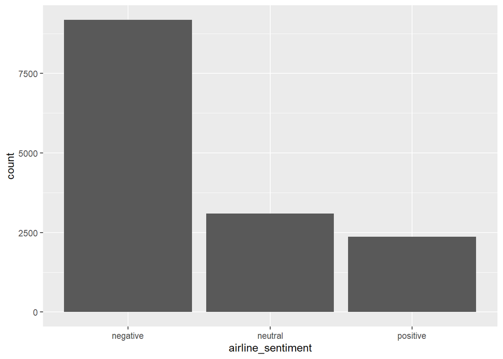

```r
# 항공사에 대한 평가 내용 분포 확인하기
ggplot(data = twt, aes(x= airline_sentiment)) + geom_bar()
```

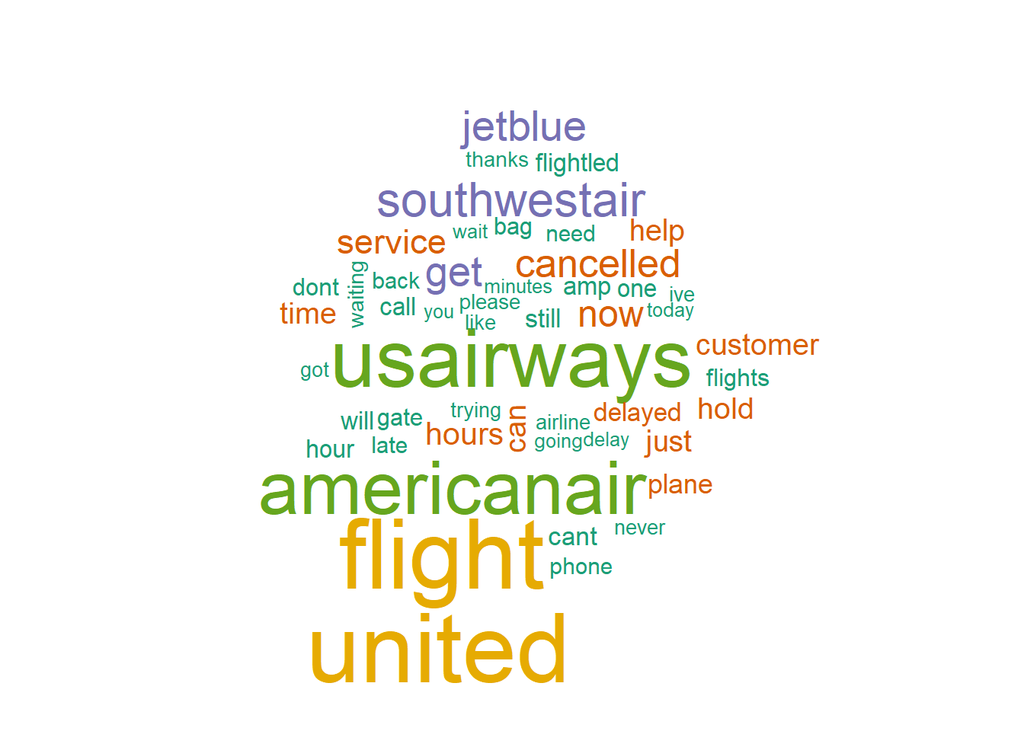

```r
# Negative, Positive, Neutral 메시지 분리
neg <- subset(twt, airline_sentiment == "negative")
pos <- subset(twt, airline_sentiment == "positive")
neu <- subset(twt, airline_sentiment == "neutral")

# Negative한 평가의 트윗에 자주 포함되어있는 단어 확인해보기
wordcloud(neg$text, max.words = 50, colors = brewer.pal(6, "Dark2"))
```

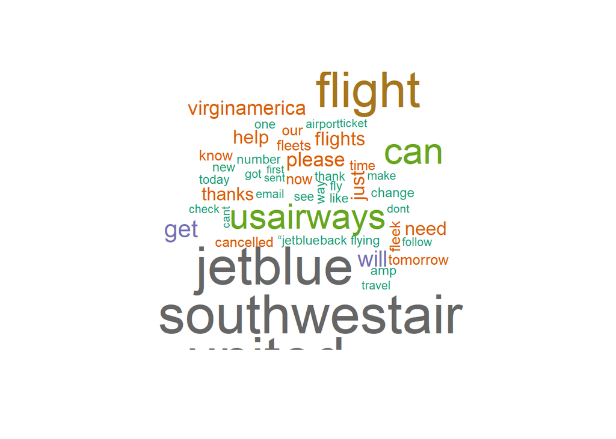

```r
# Neutral한 평가의 트윗에 자주 포함되어있는 단어 확인해보기
wordcloud(neu$text, max.words = 50, colors = brewer.pal(8, "Dark2"))
```

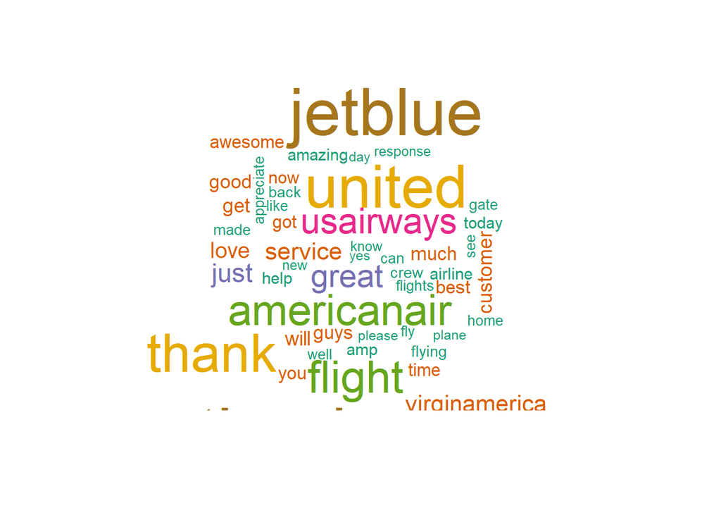

```r
# Positive한 평가의 트윗에 자주 포함되어있는 단어 확인해보기
wordcloud(pos$text, max.words = 50, colors = brewer.pal(7, "Dark2"))
```

빈도가 높게 나타난 단어들을 살펴보면, 전체적으로 united, american air, us airways 등 항공사를 지칭하는 단어가 제일 많았다. 사람들이 평가를 할 때 주로 특정 항공사를 언급하며 트윗 남긴다는 것을 알 수 있다.  
Negative 평가에서는 delayed, cancelled, time, help 등이 많이 나타났고,  
Neural 평가에서는 thank, need, just, tomorrow 등이 많이 나타났으며,  
Positive 평가에서는 great, love, best, service, good 등이 많이 나타났다.

**Negative한 평가에서는 주로 부정을한 이유, Positive 평가에서는 주로 칭찬에 대한 단어가 많이 분포한다는 특징을 알 수 있다.**

### 2. Bag of words 기법 적용을 위한 Pre-processing

#### 2.1 Corpus 생성

```r
# 평가 내용, 텍스트를 제외하고 다른 feauture를 제외한다.
twt <- twt[,c(2,11)]

# Target을 factor로 변환시켜준다.
twt$airline_sentiment <- factor(twt$airline_sentiment)

# corpus(말뭉치) 생성하기
twtcor <- VCorpus(VectorSource(twt$text))

# 생성된 말뭉치 확인해보기
twtcor
```

```
## <<VCorpus>>
## Metadata:  corpus specific: 0, document level (indexed): 0
## Content:  documents: 14640
```

```r
# 생성된 말뭉치의 구성요소들 살펴보기
inspect(twtcor[[620]])
```

```
## <<PlainTextDocument>>
## Metadata:  7
## Content:  chars: 53
##
## @united ua1673 still waiting! Supposed to depart 9:08
```

```r
twtcor[[620]]$content
```

```
## [1] "@united ua1673 still waiting! Supposed to depart 9:08"
```

620번째 트윗은 53개의 문자(알파벳)을 포함하고 있었으며  
United 항공이 늦게 출발한다는 내용의 트윗이었다.

#### 2.2 대소문자 통합, 모두 소문자로 변환

```r
# 대문자를 모두 소문자로 변환한다.
# 이 때 tolower은 tm패키지 안에 속한 함수가 아니라 변환을 하여 넣는다.
twtcor_pre <- tm_map(twtcor, content_transformer(tolower))

# 모두 소문자로 잘 변환되어있는지 확인하기
twtcor_pre[[620]]$content
```

```
## [1] "@united ua1673 still waiting! supposed to depart 9:08"
```

확인결과 S가 소문자로 잘 변환되었다.

#### 2.3 숫자 제거

```r
# 숫자를 제거한다.
twtcor_pre <- tm_map(twtcor_pre, removeNumbers)

# 숫자가 잘 제거되었는지 확인하기
twtcor_pre[[620]]$content
```

```
## [1] "@united ua still waiting! supposed to depart :"
```

편명과 시간 등 숫자가 모두 제거되었다.

#### 2.4 불용어 제거

```r
# 불용어 출력해보기
stopwords()
```

```
##   [1] "i"          "me"         "my"         "myself"     "we"
##   [6] "our"        "ours"       "ourselves"  "you"        "your"
##  [11] "yours"      "yourself"   "yourselves" "he"         "him"
##  [16] "his"        "himself"    "she"        "her"        "hers"
##  [21] "herself"    "it"         "its"        "itself"     "they"
##  [26] "them"       "their"      "theirs"     "themselves" "what"
##  [31] "which"      "who"        "whom"       "this"       "that"
##  [36] "these"      "those"      "am"         "is"         "are"
##  [41] "was"        "were"       "be"         "been"       "being"
##  [46] "have"       "has"        "had"        "having"     "do"
##  [51] "does"       "did"        "doing"      "would"      "should"
##  [56] "could"      "ought"      "i'm"        "you're"     "he's"
##  [61] "she's"      "it's"       "we're"      "they're"    "i've"
##  [66] "you've"     "we've"      "they've"    "i'd"        "you'd"
##  [71] "he'd"       "she'd"      "we'd"       "they'd"     "i'll"
```

[output cut: 20 more lines]

```r
# 불용어 제거하기
twtcor_pre <- tm_map(twtcor_pre, removeWords, stopwords())

# 잘 제거되었는지 확인하기
twtcor_pre[[620]]$content
```

```
## [1] "@united ua still waiting! supposed  depart :"
```

불용어인 to가 제거되었다.

#### 2.5 문장부호 제거

```r
# 문장부호 제거하기
twtcor_pre <-tm_map(twtcor_pre, removePunctuation)

# 잘 제거되었는지 확인해보기
twtcor_pre[[620]]$content
```

```
## [1] "united ua still waiting supposed  depart "
```

@와 : 등 문장부호가 잘 제거되었다.

#### 2.6 어간 추출

```r
# snowballC 패키지를 사용하여 stemming 하기
twtcor_pre <- tm_map(twtcor_pre, stemDocument)

# stemming 결과 확인하기
twtcor_pre[[620]]$content
```

```
## [1] "unit ua still wait suppos depart"
```

#### 2.7 공백 제거

```r
# preprocessing 과정 중 발생한 공백 제거
twtcor_pre <- tm_map(twtcor_pre, stripWhitespace)

# 공백 잘 제거됐는지 확인하기
twtcor_pre[[620]]$content
```

```
## [1] "unit ua still wait suppos depart"
```

### 3. Predictive model 만들기

#### A. 지금까지 학습한 모델 활용

**모든 단어를 포함하는 모델을 만들면, 빈도가 적은 특정 단어에 모델이 Overfitting될 수 있는 단점이 존재한다.**  
따라서 TF-IDF나 DTM을 활용하여 Feature Reduction을 적절히 수행한 모델을 먼저 만들어주자.

#### A.1 TF-IDF 모델 만들기

```r
# 단어의 출현 빈도 행렬(DTM)생성하기
twt_dtm <- DocumentTermMatrix(twtcor_pre)

# TF-IDF를 계산한 Matrix 만들기
twt_tfidf <- weightTfIdf(twt_dtm)

# 계속 확인한 620번 째 트윗의 tf-idf 확인해보기
inspect(twt_tfidf[620,])
```

```
## <<DocumentTermMatrix (documents: 1, terms: 11274)>>
## Non-/sparse entries: 5/11269
## Sparsity           : 100%
## Maximal term length: 46
## Weighting          : term frequency - inverse document frequency (normalized) (tf-idf)
## Sample             :
##      Terms
## Docs  ‘connect’ ‘select ’ll ’re ’ve   depart     still   suppos      unit
##   620           0        0    0    0    0 1.475639 0.9427013 1.413889 0.3850226
##      Terms
## Docs       wait
##   620 0.8735972
```

```r
# 전체 트윗 중 특정 퍼센트 미만의 트윗에서 발생하는 단어 제외
twt_tfidf_rmv1 <- removeSparseTerms(twt_tfidf, 0.9975)
twt_tfidf_rmv2 <- removeSparseTerms(twt_tfidf, 0.995)
twt_tfidf_rmv3 <- removeSparseTerms(twt_tfidf, 0.99)

twt_tfidf_rmv1
```

```
## <<DocumentTermMatrix (documents: 14640, terms: 564)>>
## Non-/sparse entries: 102835/8154125
## Sparsity           : 99%
## Maximal term length: 17
## Weighting          : term frequency - inverse document frequency (normalized) (tf-idf)
```

```r
twt_tfidf_rmv2
```

```
## <<DocumentTermMatrix (documents: 14640, terms: 330)>>
## Non-/sparse entries: 90845/4740355
## Sparsity           : 98%
## Maximal term length: 17
## Weighting          : term frequency - inverse document frequency (normalized) (tf-idf)
```

```r
twt_tfidf_rmv3
```

```
## <<DocumentTermMatrix (documents: 14640, terms: 160)>>
## Non-/sparse entries: 73658/2268742
## Sparsity           : 97%
## Maximal term length: 13
## Weighting          : term frequency - inverse document frequency (normalized) (tf-idf)
```

**TF-IDF 특정 %미만의 발생 단어 제외 시 남은 단어 수 비교**

[output not shown]

#### A.2 Document Term Matrix 만들기 및 Feature Reduction

```r
# 특정 빈도 이상 발생하는 단어 추출해보기
findFreqTerms(twt_dtm, lowfreq = 200)
```

```
##   [1] "agent"         "airlin"        "airport"       "americanair"
##   [5] "amp"           "anoth"         "back"          "bag"
##   [9] "baggag"        "board"         "book"          "call"
##  [13] "can"           "cancel"        "chang"         "check"
##  [17] "connect"       "crew"          "custom"        "day"
##  [21] "delay"         "due"           "email"         "even"
##  [25] "ever"          "experi"        "first"         "fli"
##  [29] "flight"        "flightl"       "follow"        "gate"
##  [33] "get"           "give"          "good"          "got"
##  [37] "great"         "guy"           "help"          "hold"
##  [41] "home"          "hope"          "hour"          "hrs"
##  [45] "issu"          "jetblu"        "just"          "know"
##  [49] "last"          "late"          "leav"          "let"
##  [53] "like"          "line"          "look"          "lost"
##  [57] "love"          "luggag"        "made"          "make"
##  [61] "min"           "minut"         "miss"          "much"
##  [65] "need"          "never"         "new"           "next"
##  [69] "now"           "number"        "one"           "passeng"
##  [73] "peopl"         "phone"         "plane"         "pleas"
##  [77] "problem"       "realli"        "rebook"        "reserv"
##  [81] "respons"       "right"         "say"           "seat"
##  [85] "see"           "servic"        "sit"           "someon"
##  [89] "southwestair"  "still"         "take"          "tell"
##  [93] "thank"         "ticket"        "time"          "today"
##  [97] "told"          "tomorrow"      "travel"        "tri"
## [101] "trip"          "two"           "unit"          "usairway"
## [105] "use"           "virginamerica" "wait"          "want"
## [109] "way"           "weather"       "will"          "work"
## [113] "worst"         "yes"
```

```r
findFreqTerms(twt_dtm, lowfreq = 300)
```

```
##  [1] "agent"         "airlin"        "airport"       "americanair"
##  [5] "amp"           "back"          "bag"           "board"
##  [9] "book"          "call"          "can"           "cancel"
## [13] "chang"         "check"         "connect"       "custom"
## [17] "day"           "delay"         "even"          "fli"
## [21] "flight"        "flightl"       "gate"          "get"
## [25] "good"          "got"           "great"         "guy"
## [29] "help"          "hold"          "hour"          "hrs"
## [33] "jetblu"        "just"          "know"          "last"
## [37] "late"          "like"          "make"          "min"
## [41] "minut"         "miss"          "need"          "never"
## [45] "now"           "one"           "phone"         "plane"
## [49] "pleas"         "problem"       "realli"        "say"
## [53] "seat"          "servic"        "southwestair"  "still"
## [57] "take"          "thank"         "ticket"        "time"
## [61] "today"         "tomorrow"      "travel"        "tri"
## [65] "unit"          "usairway"      "virginamerica" "wait"
## [69] "want"          "way"           "weather"       "will"
## [73] "work"
```

```r
findFreqTerms(twt_dtm, lowfreq = 500)
```

```
##  [1] "airlin"        "americanair"   "amp"           "back"
##  [5] "bag"           "book"          "call"          "can"
##  [9] "cancel"        "custom"        "day"           "delay"
## [13] "fli"           "flight"        "flightl"       "gate"
## [17] "get"           "help"          "hold"          "hour"
## [21] "jetblu"        "just"          "need"          "now"
## [25] "one"           "plane"         "pleas"         "seat"
## [29] "servic"        "southwestair"  "still"         "thank"
## [33] "time"          "tri"           "unit"          "usairway"
## [37] "virginamerica" "wait"          "will"
```

```r
# 현재 단어 개수 확인하기
twt_dtm
```

```
## <<DocumentTermMatrix (documents: 14640, terms: 11274)>>
## Non-/sparse entries: 136251/164915109
## Sparsity           : 100%
## Maximal term length: 46
## Weighting          : term frequency (tf)
```

```r
# 전체 트윗 중 특정 퍼센트 미만의 트윗에서 발생하는 단어 제외
twt_dtm_rmv1 <- removeSparseTerms(twt_dtm, 0.9975)
twt_dtm_rmv2 <- removeSparseTerms(twt_dtm, 0.995)
twt_dtm_rmv3 <- removeSparseTerms(twt_dtm, 0.99)

twt_dtm_rmv1
```

```
## <<DocumentTermMatrix (documents: 14640, terms: 564)>>
## Non-/sparse entries: 102835/8154125
## Sparsity           : 99%
## Maximal term length: 17
## Weighting          : term frequency (tf)
```

```r
twt_dtm_rmv2
```

```
## <<DocumentTermMatrix (documents: 14640, terms: 330)>>
## Non-/sparse entries: 90845/4740355
## Sparsity           : 98%
## Maximal term length: 17
## Weighting          : term frequency (tf)
```

```r
twt_dtm_rmv3
```

```
## <<DocumentTermMatrix (documents: 14640, terms: 160)>>
## Non-/sparse entries: 73658/2268742
## Sparsity           : 97%
## Maximal term length: 13
## Weighting          : term frequency (tf)
```

**DTM 특정 %미만의 발생 단어 제외 시 남은 단어 수 비교**

[output not shown]

같은 % 미만의 단어를 없앴을 때 남는 feature(단어)의 수는 같다는 것을 알 수 있다.  
TF-IDF모델과 비교를 해주기 위해서 같은 0.5%미만 모델을 선택하자.  
따라서 **twt_dtm_rmv2**이라는 DTM 모델을 최종적으로 선택하자.

#### A.3 Pre-processing 및 Training/Test set 분리

```r
# 먼저 만든 TF-IDF 모델과 DTM 모델을 데이터프레임으로 변환.
tw_tfidf <- as.data.frame(as.matrix(twt_tfidf_rmv2))
tw_dtm <- data.frame(as.matrix(twt_dtm_rmv2))

# feature의 이름 조정하기
colnames(tw_tfidf) <- make.names(colnames(tw_tfidf))
colnames(tw_dtm) <- make.names(colnames(tw_dtm))
```

각 데이터프레임의 형태에 대한 확인은 수행하였으며, 많은 feature 수에 의해 보고서가 너무 길어질 것 같으므로 str(tw+tfidf)함수와 str(tw_dtm)함수는 코드에서 생략하였다.

```r
# 첫 5000개의 데이터만 training set으로 사용, 나머지는 test set으로 사용
tw_tfidf_train <- tw_tfidf[1:5000,]
tw_tfidf_test <- tw_tfidf[5001:14640,]

tw_dtm_train <- tw_dtm[1:5000,]
tw_dtm_test <- tw_dtm[5001:14640,]

# Confusion Matrix에 사용할 Test set의 feature만 따로 만들어주자.
tw_test <- twt$airline_sentiment[5001:14640]
```

지금까지 K-nn, Linear Regression, Logistics Regression, Dicision Tree, Support Vector Machine 등의 Prediction Model을 학습하였다.  
Target Feature가 Negative, Positive, Neutral의 세개 범주를 가지므로 Linear Regression 대신 Logistics Regression을 사용해야한다.  
그 외에는 모두 사용할 수 있으므로 사용해보고자 한다.  
Linear Regression을 제외한 4개 모델에 대해 각각 TF-IDF 모델과 DTM 모델의 결과를 모두 비교해볼 예정이다.

#### K-NN Model

Cross Validation을 활용하여 Best Model을 찾으려 하였으나, Feature의 수가 너무 많아 Fold수 등을 많이 줄여주었음에도 불구하고 코드가 끝나지 않았다. CV를 이용한 Cross Validation의 코드는 주석으로만 남겨둔다.

```r
# Cross Validation을 위해 Training Dataset에 Target Feature를 포함시켜준다.
tw_tfidf_trainf <- cbind(tw_tfidf_train, twt$airline_sentiment[1:5000])
tw_dtm_trainf <- cbind(tw_dtm_train, twt$airline_sentiment[1:5000])

# Target 이름 바꿔주기
names(tw_tfidf_trainf)[331] <- c("sentiment")
names(tw_dtm_trainf)[331] <- c("sentiment")

# z-score normalization 사용
#z_normal <- c("center", "scale")

# 계산 시간을 고려해 3-fold cross Validation을 3회만 수행해주자.
#set.seed(100)
#knn_cv <- trainControl(method = "repeatedcv", number = 3, repeats = 3)

# 파라미터 튜닝, k를 1부터 19까지 홀수 값에 대해서만 해준다.
#knn_tune_grid <- expand.grid( mtry = seq(1, 9, 2))

# 모델 Validation: TF-IDF 모델
#twt_knn <- train(data = tw_tfidf_trainf, sentiment~., mehtod = "knn",
#                  trControl = knn_cv, preProcess = z_normal, tuneGrid = knn_tune_grid)

# 모델 Validation: TF-IDF 모델
#twt_knn <- train(data = tw_dtm_trainf, sentiment~., mehtod = "knn",
#                  trControl = knn_cv, preProcess = z_normal, tuneGrid = knn_tune_grid)
```

**Cross Validation 대신에 다양한 K에 대해서만 검증하고, KNN을 실행해보고자 한다.**